# FIRST HOMEWORK: UNSUPERVISED LEARNING

## 6.1 METHOD 1: Fit a 4-factor model with no rotation.

### 6.1.1 STEP 1: Perform factor analysis.

In the R software factor analysis is implemented by the ‘factanal()’ function. The function performs maximum-likelihood factor analysis on a covariance matrix or data matrix. Just to be in context, the MLE (Maximum Likelihood Estimator), is a technique used for estimating the parameters of a given distribution, using some observed data.

The number of factors to be fitted is specified by the argument factors. Further, the factor scores may be calculated either by using Thompson’s estimator or Bartlett’s weighted least-squares scores method. The particular method is specified by an additional argument scores = “regression” or scores = “Bartlett”. Moreover, by the additional argument rotation the transformation of the factors may be specified by either rotation = “varimax” for orthogonal rotation, rotation = “Bartlett” for oblique rotation or rotation = “none”.

A 4-factor model with no rotation is fitted.

```r
x.f <- factanal(fa, factors = 4, rotation="none", scores="regression")
x.f
```

```
##
## Call:
## factanal(x = fa, factors = 4, scores = "regression", rotation = "none")
##
## Uniquenesses:
##                               Age                   Flight.Distance
##                             0.986                             0.973
##             Inflight.wifi.service Departure.Arrival.time.convenient
##                             0.385                             0.777
##            Ease.of.Online.booking                     Gate.location
##                             0.115                             0.765
##                    Food.and.drink                   Online.boarding
##                             0.409                             0.676
##                      Seat.comfort            Inflight.entertainment
##                             0.390                             0.199
##                  On.board.service                  Leg.room.service
##                             0.506                             0.753
##                  Baggage.handling                   Checkin.service
##                             0.413                             0.916
##                  Inflight.service                       Cleanliness
##                             0.345                             0.258
##        Departure.Delay.in.Minutes          Arrival.Delay.in.Minutes
##                             0.063                             0.005
##
## Loadings:
##                                   Factor1 Factor2 Factor3 Factor4
## Age
## Flight.Distance                    0.156
## Inflight.wifi.service              0.620  -0.479
## Departure.Arrival.time.convenient  0.293  -0.367
## Ease.of.Online.booking             0.596  -0.727
## Gate.location                      0.275  -0.398
## Food.and.drink                     0.536   0.416          -0.359
## Online.boarding                    0.546                  -0.127
## Seat.comfort                       0.568   0.431          -0.317
## Inflight.entertainment             0.721   0.526
## On.board.service                   0.365   0.218           0.558
## Leg.room.service                   0.309                   0.378
## Baggage.handling                   0.345   0.200           0.654
## Checkin.service                    0.198   0.129           0.167
## Inflight.service                   0.353   0.214           0.693
## Cleanliness                        0.615   0.496          -0.343
## Departure.Delay.in.Minutes                         0.968
## Arrival.Delay.in.Minutes                           0.997
##
##                Factor1 Factor2 Factor3 Factor4
## SS loadings      3.253   2.105   1.942   1.765
## Proportion Var   0.181   0.117   0.108   0.098
## Cumulative Var   0.181   0.298   0.406   0.504
##
## Test of the hypothesis that 4 factors are sufficient.
## The chi square statistic is 64966.82 on 87 degrees of freedom.
## The p-value is 0
```

This gives us as an output several information. Among the key points to consider are:

1. Uniqueness. It is the variance that is ‘unique’ to the variable and not shared with other variables. It ranges from 0 to 1 and is referred to as ‘noise’. If it is very close to 1, the variable does not explain very good the variance of our model.
2. Loadings. It ranges from -1 to 1. The loadings are the contribution of each original variable to the factor. Variables with a high loading are well explained by the factor. The higher the value, the better.
3. The table beneath the loadings shows the proportion of variance explained by each factor. The row ‘Cumulative Var’ gives the cumulative proportion of variance explained. These numbers range from 0 to 1. The row ‘Proportion Var’ gives the proportion of variance explained by each factor, and the row ‘SS loadings’ gives the sum of squared loadings. Note: A factor is worth keeping if the SS loading is greater than 1 (Kaiser’s rule).
4. The last section of the function output shows the results of a hypothesis test. The null hypothesis, H0, is that the number of factors in the model is sufficient to capture the full dimensionality of the data set. Conversely, we reject H0 if the p-value is less than 0.05.

```r
cbind(x.f$loadings, x.f$uniquenesses)
```

```
##                                       Factor1       Factor2      Factor3
## Age                               0.086519931  0.0290152091 -0.012224446
## Flight.Distance                   0.155785208  0.0489112680 -0.002487791
## Inflight.wifi.service             0.620482076 -0.4788716432 -0.019962028
## Departure.Arrival.time.convenient 0.293419481 -0.3673332348 -0.001091883
## Ease.of.Online.booking            0.595719281 -0.7271172401 -0.008537190
## Gate.location                     0.274660715 -0.3980159612  0.004966819
## Food.and.drink                    0.536395547  0.4164267594 -0.033753619
## Online.boarding                   0.545694522 -0.0969394948 -0.022822259
## Seat.comfort                      0.568313088  0.4308584565 -0.031217895
## Inflight.entertainment            0.721457996  0.5264410204 -0.032544385
## On.board.service                  0.365122695  0.2184274867 -0.036294692
## Leg.room.service                  0.308655432  0.0930077638  0.011204521
## Baggage.handling                  0.345426668  0.2001405086 -0.009540597
## Checkin.service                   0.198489126  0.1291409787 -0.020899996
## Inflight.service                  0.353461136  0.2142039737 -0.060335516
## Cleanliness                       0.615284054  0.4961368142 -0.017204850
## Departure.Delay.in.Minutes        0.005035571  0.0012705920  0.967894624
## Arrival.Delay.in.Minutes          0.001815202  0.0007441241  0.997494904
##                                         Factor4
## Age                               -0.0770735739 0.98558167
## Flight.Distance                    0.0174829016 0.97302314
## Inflight.wifi.service              0.0039590955 0.38527123
## Departure.Arrival.time.convenient  0.0436052243 0.77706960
## Ease.of.Online.booking            -0.0311835075 0.11537388
## Gate.location                     -0.0307850318 0.76517259
## Food.and.drink                    -0.3592314858 0.40868136
## Online.boarding                   -0.1267608788 0.67623154
## Seat.comfort                      -0.3172854549 0.38973553
## Inflight.entertainment             0.0433148530 0.19942260
## On.board.service                   0.5581575935 0.50611677
## Leg.room.service                   0.3784084933 0.75276291
## Baggage.handling                   0.6536253067 0.41330814
## Checkin.service                    0.1668453086 0.91565341
## Inflight.service                   0.6932535259 0.34494249
## Cleanliness                       -0.3425361371 0.25764591
## Departure.Delay.in.Minutes         0.0025162498 0.06314708
## Arrival.Delay.in.Minutes           0.0002910441 0.00500000
```

### 6.1.2 STEP 2: Conclusions.

As observed in the results from above, several conclusions can be reached:

1. First off, regarding uniqueness, it looks as though those certain variables do not explain very well the variance of our model (‘Age’, ‘Flight.Distance’, ‘Departure.Arrival.time.convenient’, ‘Gate.location’, ‘Leg.room.service’ and ‘Checkin.service’).
2. Secondly, loadings need an extense explanation:

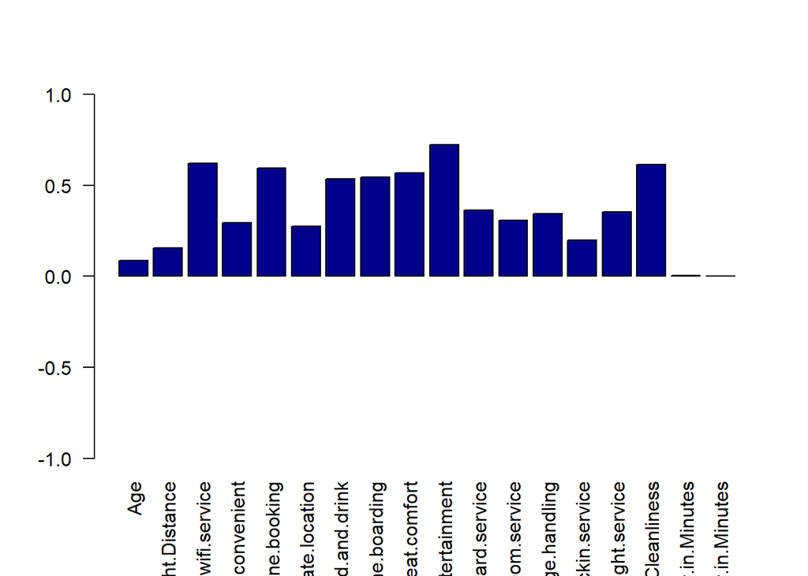

```r
# Interpretation of factor 1.
barplot(x.f$loadings[,1], las=2, col="darkblue", ylim = c(-1, 1))
```

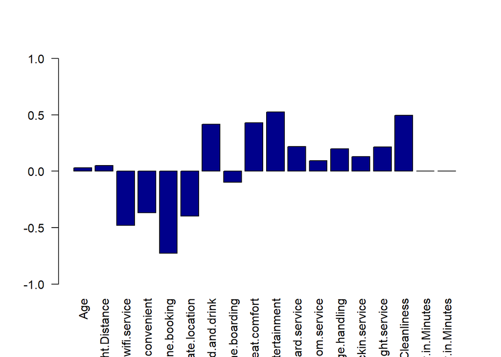

```r
# The first factor is highly correlated correlated with three of the
# original variables. The first factor increases with increasing
# 'Inflight.wifi.service', 'Inflight.entertainment', and 'Cleanliness'.
# This suggests that these three criteria vary together. If one increases,
# then the remaining ones tend to increase as well. Furthermore, we see that
# the first factor correlates most strongly with the 'Inflight.entertainment'
# (0.721457996).


# Interpretation of factor 2.
barplot(x.f$loadings[,2], las=2, col="darkblue", ylim = c(-1, 1))
```

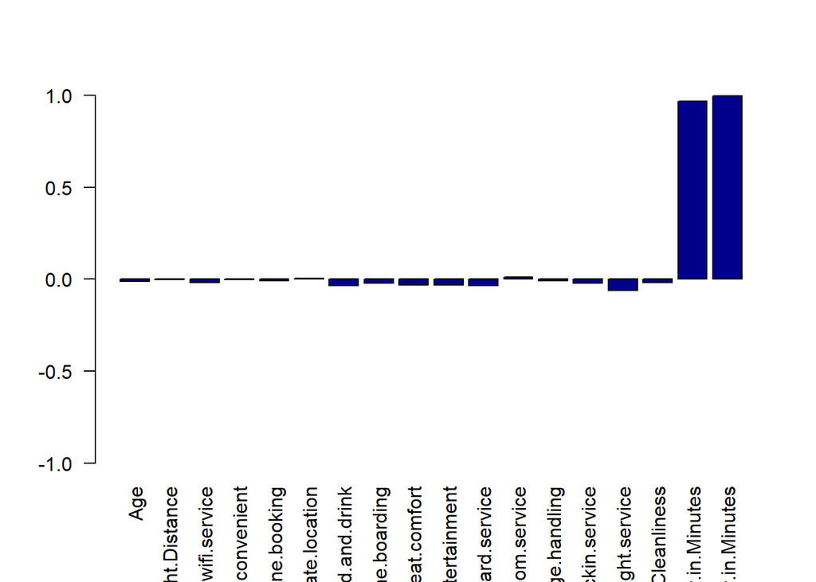

```r
# The second factor increases with one of the variables, decreasing
# 'Ease.of.Online.booking'. This factor can be viewed as a measure of how
# satisfied are passengers in terms of how easy it is to do online booking.


# Interpretation of factor 3.
barplot(x.f$loadings[,3], las=2, col="darkblue", ylim = c(-1, 1))
```

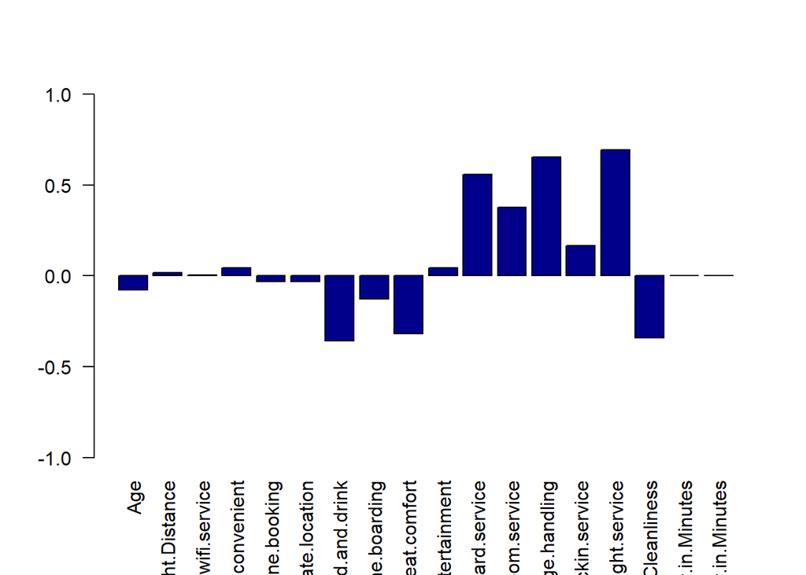

```r
# The third factor increases with increasing 'Departure.Delay.in.Minutes' and
# 'Arrival.Delay.in.Minutes', containing the highest correlation (0.968, 0,997;
# respectively).


# Interpretation of factor 4.
barplot(x.f$loadings[,4], las=2, col="darkblue", ylim = c(-1, 1))
```

```r
# For the fourth and last factor, it increases with increasing 'Baggage.handling' and
# 'Inflight.service', even the correlation is not has high as it is desired to be.
# However, these two are the ones that contain the highest correlation with the
# last factor (0.6536253067, 0.6932535259; respectively).
```

3. Regarding the SS loadings, one can tell that, as of right now, all the factors are worth being maintained due to Kaiser’s rule.
4. Finally, related to the p-value, since it is 0, it means that it is a must to reject the hypothesis. That is, 4 factors are not enough, contrary to our initial hypothesis.

## 6.2 METHOD 2: Fit a 4-factor model with rotation varimax and Barlett estimation for scores.

The varimax technique makes some of these loadings as large as feasible and the rest as little as possible in absolute value by maximizing the variance of the squared loadings for each factor. As a result, the variables can be divided into groups where each group has strong loadings on one factor, moderate to low loadings on a few factors, and negligible loadings on the remaining factors. The varimax technique promotes the discovery of factors, each of which is associated with a small number of variables. It discourages the identification of elements affecting every variable.

### 6.2.1 STEP 1: Perform factor analysis.

```r
x.f2 <- factanal(fa, factors = 4, rotation="varimax", scores="Bartlett", lower = 0.01)
x.f2
```

```
##
## Call:
## factanal(x = fa, factors = 4, scores = "Bartlett", rotation = "varimax",     lower = 0.01)
##
## Uniquenesses:
##                               Age                   Flight.Distance
##                             0.986                             0.973
##             Inflight.wifi.service Departure.Arrival.time.convenient
##                             0.385                             0.777
##            Ease.of.Online.booking                     Gate.location
##                             0.115                             0.765
##                    Food.and.drink                   Online.boarding
##                             0.409                             0.676
##                      Seat.comfort            Inflight.entertainment
##                             0.390                             0.199
##                  On.board.service                  Leg.room.service
##                             0.506                             0.753
##                  Baggage.handling                   Checkin.service
##                             0.413                             0.916
##                  Inflight.service                       Cleanliness
##                             0.345                             0.258
##        Departure.Delay.in.Minutes          Arrival.Delay.in.Minutes
##                             0.058                             0.010
##
## Loadings:
##                                   Factor1 Factor2 Factor3 Factor4
## Age                                0.114
## Flight.Distance                    0.122
## Inflight.wifi.service              0.170   0.133   0.754
## Departure.Arrival.time.convenient                  0.468
## Ease.of.Online.booking                             0.939
## Gate.location                                      0.484
## Food.and.drink                     0.768
## Online.boarding                    0.386           0.406
## Seat.comfort                       0.775
## Inflight.entertainment             0.742   0.499
## On.board.service                           0.698
## Leg.room.service                           0.483
## Baggage.handling                           0.765
## Checkin.service                    0.116   0.266
## Inflight.service                           0.808
## Cleanliness                        0.854   0.115
## Departure.Delay.in.Minutes                                 0.970
## Arrival.Delay.in.Minutes                                   0.994
##
##                Factor1 Factor2 Factor3 Factor4
## SS loadings      2.701   2.346   2.085   1.933
## Proportion Var   0.150   0.130   0.116   0.107
## Cumulative Var   0.150   0.280   0.396   0.504
##
## Test of the hypothesis that 4 factors are sufficient.
## The chi square statistic is 64967.32 on 87 degrees of freedom.
## The p-value is 0
```

```r
# From the results, it is desired to analyze 'loadings' (a matrix of loadings,
# one column for each factor. The factors are ordered in decreasing order of
# sums of squares of loadings, and given the sign that will make the sum of
# the loadings positive) and 'uniqueness' (the variance that is 'unique' to
# the variable and not shared with other variables)
cbind(x.f2$loadings, x.f2$uniquenesses)
```

```
##                                        Factor1     Factor2      Factor3
## Age                                0.113987347 -0.02014260  0.030477124
## Flight.Distance                    0.122211184  0.09604297  0.052963741
## Inflight.wifi.service              0.169583352  0.13265343  0.753839416
## Departure.Arrival.time.convenient -0.015085280  0.05771306  0.468371506
## Ease.of.Online.booking             0.041153590  0.02025445  0.939415797
## Gate.location                     -0.005531296 -0.02295930  0.483979801
## Food.and.drink                     0.767619349  0.04374074 -0.004561198
## Online.boarding                    0.385711312  0.09865585  0.406430011
## Seat.comfort                       0.775050307  0.09744352  0.001627106
## Inflight.entertainment             0.742445240  0.49931230  0.005594536
## On.board.service                   0.074103815  0.69810990  0.025894120
## Leg.room.service                   0.061990198  0.48292691  0.098054492
## Baggage.handling                   0.001135931  0.76548115  0.026004871
## Checkin.service                    0.116331854  0.26567270  0.009688403
## Inflight.service                  -0.005178679  0.80799893  0.018501452
## Cleanliness                        0.853627890  0.11450547 -0.022140517
## Departure.Delay.in.Minutes        -0.023590814 -0.01633660 -0.001041566
## Arrival.Delay.in.Minutes          -0.025690193 -0.02051432 -0.002583762
##                                        Factor4
## Age                               -0.009378354 0.98557785
## Flight.Distance                    0.003375263 0.97301867
## Inflight.wifi.service             -0.010215681 0.38526552
## Departure.Arrival.time.convenient  0.001241716 0.77707867
## Ease.of.Online.booking            -0.004108787 0.11537734
## Gate.location                      0.005815548 0.76517158
## Food.and.drink                    -0.011907730 0.40868794
## Online.boarding                   -0.008874685 0.67622903
## Seat.comfort                      -0.007982741 0.38973627
## Inflight.entertainment            -0.001476718 0.19943012
## On.board.service                  -0.019014707 0.50611786
## Leg.room.service                   0.023850912 0.75275609
## Baggage.handling                   0.007265532 0.41330819
## Checkin.service                   -0.011910139 0.91565743
## Inflight.service                  -0.042896629 0.34492842
## Cleanliness                        0.008485882 0.25764592
## Departure.Delay.in.Minutes         0.969928615 0.05841361
## Arrival.Delay.in.Minutes           0.994440863 0.01000000
```